# Transformation des données

Il s’agit d’un extrait de la formation. Cette formation peut se faire en présentiel ou à distance. Pour en savoir plus, merci de me contacter.

# 1 Introduction

Les différents types de transformations des données sont multiples. Certaines transformations mathématiques permettent de construire un modèle prédictif plus robuste par la suite:

- Suppression des valeurs particulières avant la centrer-réduction
- Centrer-réduction
- Normalisation min-max
- Transformation des valeurs manquantes
- Suppression des valeurs aberrantes

D’autres transformations des données facilitent la manipulation des données comme le “remodelage” des données entre format long et large:

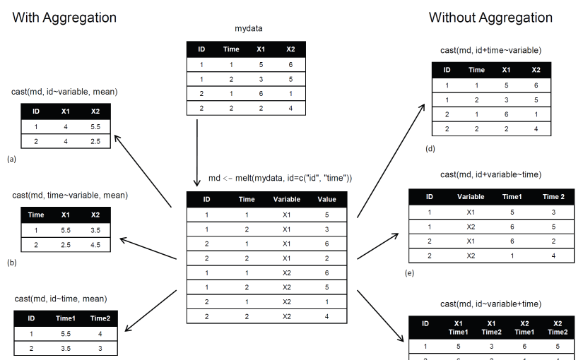

# 2 Centrer-réduction

La centrer-réduction consiste à transformer une série de données numériques en une autre série avec une moyenne nulle et une variance égale à 1.

En effet, il est important de normer les données, car cela affecte directement la distance entre deux observations.

Si deux variables ont des ordres de grandeur différents, la variable qui a des valeurs plus grandes aura une prépondérance plus grande dans la mesure de la distance.

La centrer-réduction permet ainsi de faire en sorte que toutes les variables ont le même poids dans le calcul de la distance.

# 3 Transformation min-max

Il s’agit de normaliser toutes les valeurs d’une variable en une série de valeures entre 0 et 1.

# 4 Agrégation des données

Variables catégoriques

- Comptage des catégories
- Tableau croisé

Variables numériques

- Quantiles
- Probabilités
- Autres éléments statistiques

Regroupement ou tranches

- Regroupement des modalités nombreuses: mieux voir
- Tranches: pour les variables numériques
- Attention: garder toujours les données brutes